# Homework-04

Julie Jung

October 17, 2017

[1] Write a simple R function, Z.prop.test(), that can perform one- or two-sample Z-tests for proportion data, using the following guidelines.

The function should return a list containing the members Z (the test statistic), P (the appropriate p value), and CI (the two-sided CI with respect to “conf.level” around p1 in the case of a one-sample test and around p2-p1 in the case of a two-sample test). For all test alternatives (“two.sided”, “greater”, “less”), calculate symmetric CIs based on quantiles of the normal distribution rather than worrying about calculating single-limit confidence bounds.

```r
# p1, no default == estimated sample proportion (i.e., based on your sample data)
# n1, no default == estimated sample size (i.e., based on your sample data)

# p2, default is NULL == second sample proportion data (in the event of a two-sample test)
# n2, default is NULL == second sample size data (in the event of a two-sample test)

# p0, no default == the expected value for the population proportion

# alternative (default “two.sided”), to be used in the same way as in the function t.test().
# conf.level (default 0.95), to be used in the same way as in the function t.test().

Z.prop.test <- function(p1, n1, p2=NULL, n2=NULL, p0, alternative=c("two.sided", "less", "greater"), conf.level=0.95) {

  OK <- complete.cases(p1, n1, p0)
    p1 <- p1[OK]
    n1 <- n1[OK]
    p0 <- p0[OK]

  if (n1*p1 < 5)
    warning("failed one or more validity tests; i.e. assumption is not met")
  if (n1 * (1-p1) < 5)
    warning("failed one or more validity tests; i.e. assumption is not met")

  if (is.null(c(p2,n2))) {
        z <- (p1-p0)/sqrt((p0 * (1-p0)/n1))

      lower <- p1 - qnorm(0.975) * sqrt(p1 * (1 - p1)/n1)
      upper <- p1 + qnorm(0.975) * sqrt(p1 * (1 - p1)/n1)
      ci <- c(lower, upper)

      if (alternative == "less"){
        p[i] <- pnorm(z, lower.tail=TRUE) # calculates the associated p value
      }

      if (alternative == "greater"){
        p[i] <- pnorm(z, lower.tail = FALSE)  # calculates the associated p value
      }

      if (alternative == "two.tailed") {
            if (z > 0)
                {
                  p[i] <- 2 * pnorm(z, lower.tail = FALSE)
                }
            if (z < 0)
                {
                  p[i] <- 2 * pnorm(z, lower.tail = TRUE)
                }
        }
    }

    ## if want to perform a 2-sample test
    # When conducting a two-sample test, it should be p1 that is tested as being smaller or larger than p2 when alternative=“less” or alternative=“greater”, the same as in the use of x and y in the function t.test().

  else  {
     pstar= p1+p2
     pci= p2-p1
     ntot= n1 + n2
        z <- (p2 - p1)/sqrt((pstar * (1 - pstar)) * (1/n1) + 1/n2)

    lower <- pci - qnorm(0.975) * sqrt(pci * (1 - pci)/ntot)
    upper <- pci + qnorm(0.975) * sqrt(pci * (1 - pci)/ntot)
    ci <- c(lower, upper)

        if (alternative == "less") {
            p <- pnorm(z, lower.tail = TRUE)
        }
        if (alternative == "greater") {
            p <- pnorm(z, lower.tail = FALSE)
        }
        if (alternative == "two.sided") {
            if (z > 0)
                {
                  p <- 2 * pnorm(z, lower.tail = FALSE)
                }
            if (z < 0)
                {
                  p <- 2 * pnorm(z, lower.tail = TRUE)
                }

        }
    }

  # The function should perform a one-sample Z-test using p1, n1, and p0 if either p2 or n2 (or both) is NULL.

   result <- list(statistic = z,
     p.value = p,
         conf.int = ci,
         alternative = alternative)

    return(result)
  }
```

[2] The dataset from Kamilar and Cooper has in it a large number of variables related to life history and body size.

For this exercise, the end aim is to fit a simple linear regression model to predict - longevity (MaxLongevity_m): measured in months - from species’ brain size (Brain_Size_Species_Mean): measured in grams.

```r
# Import file from github
library(curl)
f <- curl("https://raw.githubusercontent.com/fuzzyatelin/fuzzyatelin.github.io/master/AN597_Fall17/KamilarAndCooperData.csv")
d <- read.csv(f, header = TRUE, sep = ",", stringsAsFactors = FALSE)
head(d)
```

```
##               Scientific_Name          Family          Genus      Species
## 1 Allenopithecus_nigroviridis Cercopithecidae Allenopithecus nigroviridis
## 2         Allocebus_trichotis Cercopithecidae      Allocebus    trichotis
## 3           Alouatta_belzebul        Atelidae       Alouatta     belzebul
## 4             Alouatta_caraya        Atelidae       Alouatta       caraya
## 5            Alouatta_guariba        Atelidae       Alouatta      guariba
## 6           Alouatta_palliata        Atelidae       Alouatta     palliata
##   Brain_Size_Species_Mean Brain_Size_Female_Mean   Brain_size_Ref
## 1                   58.02                  53.70 Isler et al 2008
## 2                      NA                     NA
## 3                   52.84                  51.19 Isler et al 2008
## 4                   52.63                  47.80 Isler et al 2008
## 5                   51.70                  49.08 Isler et al 2008
## 6                   49.88                  48.04 Isler et al 2008
##   Body_mass_male_mean Body_mass_female_mean Mass_Dimorphism
```

[output cut: 69 more lines]

Do the following for both (1) longevity~brain size and (2) log(longevity)~log(brain size).

Fit the regression model and, using {ggplot2}, produce a scatterplot with the fitted line superimposed upon the data. Append the the fitted model equation to your plot

```r
# (1) longevity~brain size
library(ggplot2)
mI <- lm(MaxLongevity_m ~ Brain_Size_Species_Mean, data = d)
t <- coef(summary(mI))
t <- data.frame(unlist(t))
colnames(t) <- c("Est", "SE", "t", "p")
t
```

```
##                               Est         SE       t            p
## (Intercept)             248.95227 11.1111143 22.4057 8.910319e-46
## Brain_Size_Species_Mean   1.21799  0.1100879 11.0638 2.685909e-20
```

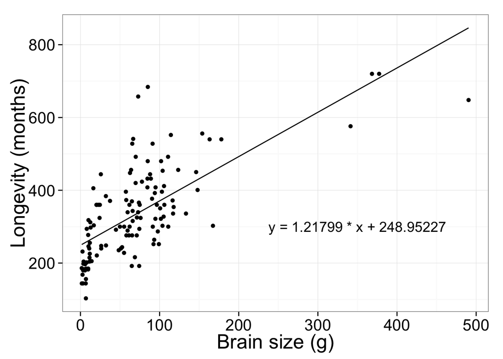

```r
beta0 <- t$Est[1] #The intercept, β0, is the PREDICTED value of y when the value of x is zero.
beta1 <- t$Est[2] #The slope, β1 is EXPECTED CHANGE in units of y for every 1 unit of change in x

ggplot(data = d, aes(x = Brain_Size_Species_Mean, y = MaxLongevity_m)) +
  geom_point()+
  geom_smooth(method="lm", se=F, color="black")+
  annotate("text", x = 350, y = 300, label = "y = 1.21799 * x + 248.95227")+
  ylab("Longevity (months)")+
  theme_bw(20) +
  xlab("Brain size (g)")
```

```r
# (2) log(longevity)~log(brain size).

mI <- lm(log(MaxLongevity_m) ~ log(Brain_Size_Species_Mean), data = d)
t <- coef(summary(mI))
t <- data.frame(unlist(t))
colnames(t) <- c("Est", "SE", "t", "p")
t
```

```
##                                    Est         SE        t             p
## (Intercept)                  4.8789509 0.06907361 70.63408 3.321721e-103
## log(Brain_Size_Species_Mean) 0.2341496 0.01780887 13.14792  2.165214e-25
```

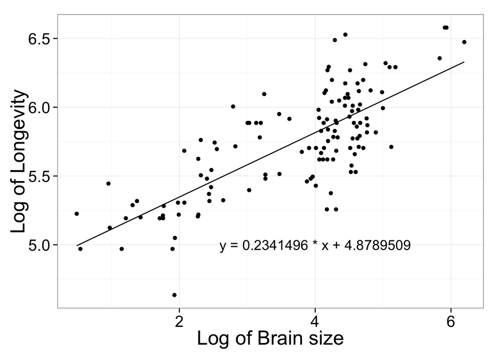

```r
beta0 <- t$Est[1] #The intercept, β0, is the PREDICTED value of y when the value of x is zero.
beta1 <- t$Est[2] #The slope, β1 is EXPECTED CHANGE in units of y for every 1 unit of change in x

ggplot(data = d, aes(x = log(Brain_Size_Species_Mean), y = log(MaxLongevity_m))) +
  geom_point()+
  geom_smooth(method="lm", se=F, color="black")+
  annotate("text", x = 4, y = 5, label = "y = 0.2341496 * x + 4.8789509")+
  ylab("Log of Longevity")+
  theme_bw(20) +
  xlab("Log of Brain size")
```

Identify and interpret the point estimate of the slope (β1), as well as the outcome of the test associated with the hypotheses H0: β1 = 0; HA: β1 ≠ 0. Also, find a 90 percent CI for the slope (β1) parameter.

–> The slope, β1 is the EXPECTED CHANGE in units of y for every 1 unit of change in x. For every gram of increase in brain size, we can expect to see an increase in longevity of β1 months. See above for values from examples.

```r
#confidence intervals for our estimates

t$lower <- t$Est - qt(0.95, df = 998) * t$SE
t$upper <- t$Est + qt(0.95, df = 998) * t$SE
ci <- c(t$lower, t$upper)  # by hand
ci
```

```
## [1] 4.7652294 0.2048294 4.9926725 0.2634698
```

```r
ci <- confint(mI, level = 0.90)  # using the results of lm()
ci
```

```
##                                    5 %      95 %
## (Intercept)                  4.7644934 4.9934084
## log(Brain_Size_Species_Mean) 0.2046396 0.2636595
```

Using your model, add lines for the 90 percent confidence and prediction interval bands on the plot and add a legend to differentiate between the lines.

```r
###### non-log model

v = seq(from = 0, to = 500, by = 1)
m = lm(data=d, MaxLongevity_m~Brain_Size_Species_Mean)
ci = predict(m, newdata = data.frame(Brain_Size_Species_Mean = v), interval = "confidence", level = 0.90)
pi = predict(m, newdata = data.frame(Brain_Size_Species_Mean = v), interval = "prediction", level = 0.90)
df <- data.frame(cbind(v, ci, pi))
names(df) <- c("Brain_Size_Species_Mean", "CIfit", "CIlwr", "CIupr", "PIfit", "PIlwr", "PIupr")
head(df)
```

```
##   Brain_Size_Species_Mean    CIfit    CIlwr    CIupr    PIfit     PIlwr
## 1                       0 248.9523 230.5407 267.3638 248.9523  97.18861
## 2                       1 250.1703 231.8842 268.4563 250.1703  98.42177
## 3                       2 251.3882 233.2268 269.5497 251.3882  99.65472
## 4                       3 252.6062 234.5683 270.6441 252.6062 100.88745
## 5                       4 253.8242 235.9089 271.7396 253.8242 102.11996
## 6                       5 255.0422 237.2484 272.8360 255.0422 103.35226
##      PIupr
## 1 400.7159
## 2 401.9187
## 3 403.1218
## 4 404.3250
## 5 405.5285
## 6 406.7322
```

```r
s <- shapiro.test(m$residuals)
s
```

```
##
##  Shapiro-Wilk normality test
##
## data:  m$residuals
## W = 0.9517, p-value = 0.0001729
```

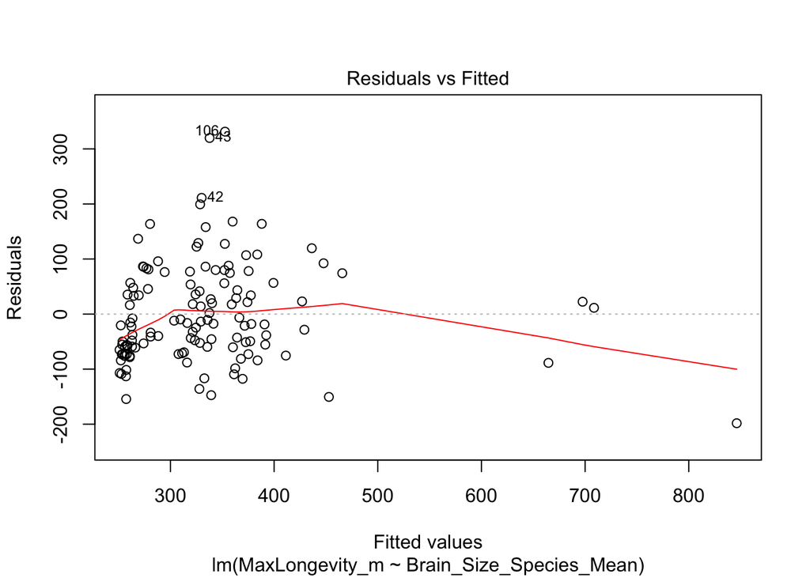

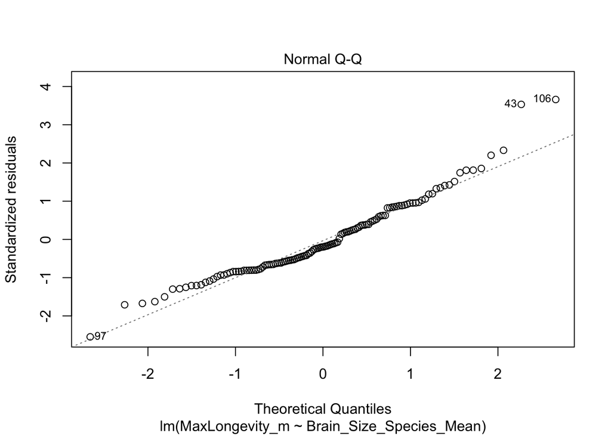

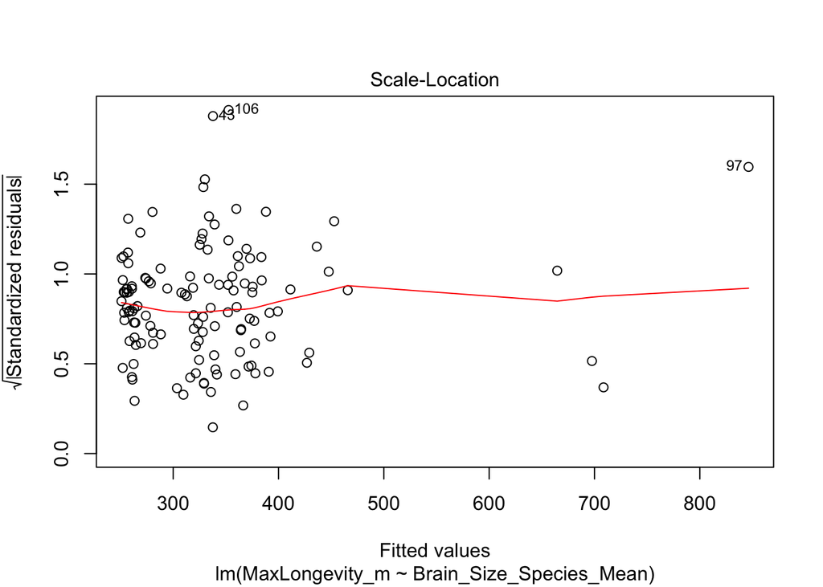

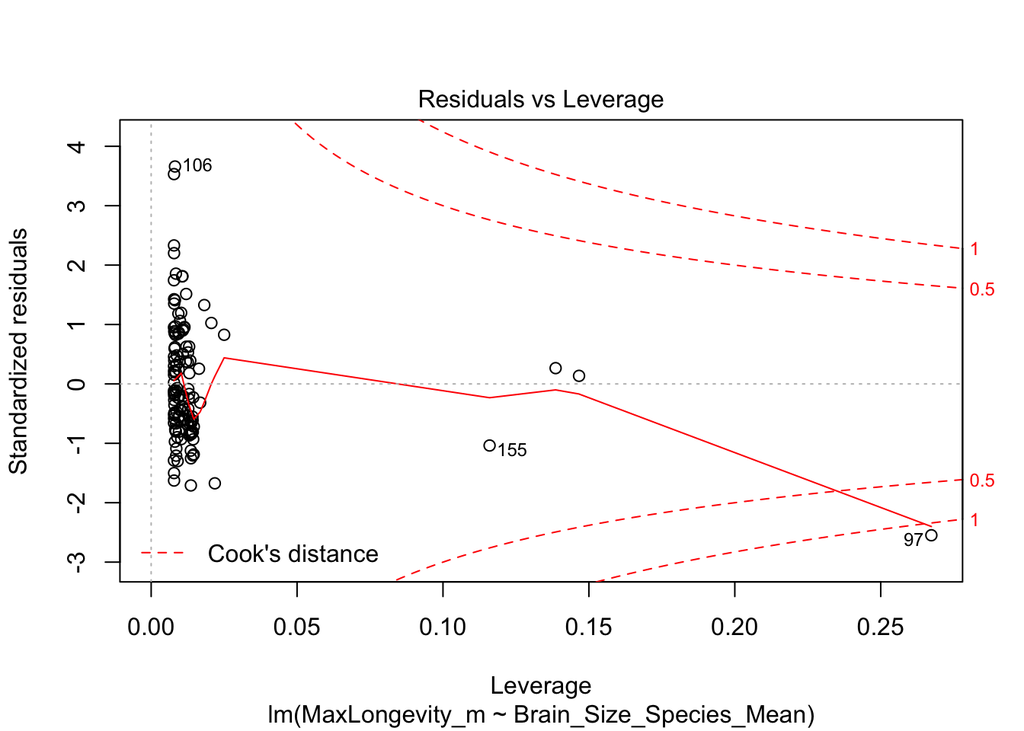

```r
plot(m)
```

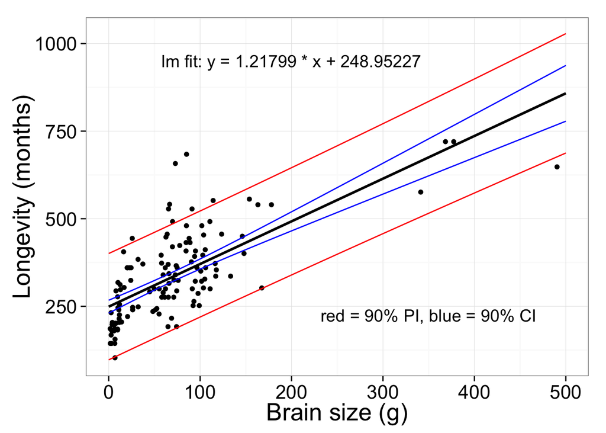

```r
ggplot(data = d, aes(x = Brain_Size_Species_Mean, y = MaxLongevity_m)) +
  geom_point()+
  geom_line(data = df, aes(x = v, y = CIfit), colour = "black", lwd = 1)+
  geom_line(data = df, aes(x = v, y = CIlwr), colour = "blue")+
  geom_line(data = df, aes(x = v, y = CIupr), colour = "blue")+
  geom_line(data = df, aes(x = v, y = PIlwr), colour = "red")+
  geom_line(data = df, aes(x = v, y = PIupr), colour = "red")+
  annotate("text", x = 200, y = 950, label = "lm fit: y = 1.21799 * x + 248.95227")+
  annotate("text", x = 350, y = 225, label = "red = 90% PI, blue = 90% CI")+
  ylab("Longevity (months)")+
  theme_bw(20) +
  xlab("Brain size (g)")
```

Produce a point estimate and associated 90 percent PI for the longevity of a species whose brain weight is 800 gm.

```r
ppi <- predict(m, newdata = data.frame(Brain_Size_Species_Mean = 800), interval = "prediction", level = 0.90)  # for a single value
ppi
```

```
##        fit      lwr      upr
## 1 1223.345 1021.805 1424.884
```

```r
### LOG model

v = seq(from = 0, to = 7, by = 1)
m = lm(data=d, log(MaxLongevity_m)~log(Brain_Size_Species_Mean))
ci = predict(m, newdata = data.frame(Brain_Size_Species_Mean = v), interval = "confidence", level = 0.90)
pi = predict(m, newdata = data.frame(Brain_Size_Species_Mean = v), interval = "prediction", level = 0.90)
df <- data.frame(cbind(v, ci, pi))
names(df) <- c("Brain_Size_Species_Mean", "CIfit", "CIlwr", "CIupr", "PIfit", "PIlwr", "PIupr")
head(df)
```

```
##   Brain_Size_Species_Mean    CIfit    CIlwr    CIupr    PIfit    PIlwr
## 1                       0     -Inf      NaN      NaN     -Inf      NaN
## 2                       1 4.878951 4.764493 4.993408 4.878951 4.451636
## 3                       2 5.041251 4.945965 5.136537 5.041251 4.618668
## 4                       3 5.136191 5.051839 5.220542 5.136191 4.715938
## 5                       4 5.203551 5.126771 5.280331 5.203551 4.784752
## 6                       5 5.255800 5.184750 5.326851 5.255800 4.838014
##      PIupr
## 1      NaN
## 2 5.306266
## 3 5.463834
## 4 5.556443
## 5 5.622350
## 6 5.673586
```

```r
s <- shapiro.test(m$residuals)
s
```

```
##
##  Shapiro-Wilk normality test
##
## data:  m$residuals
## W = 0.9926, p-value = 0.7404
```

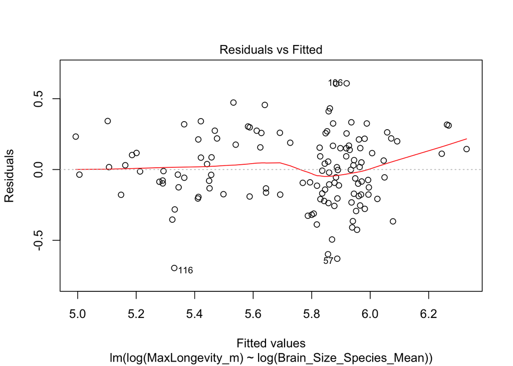

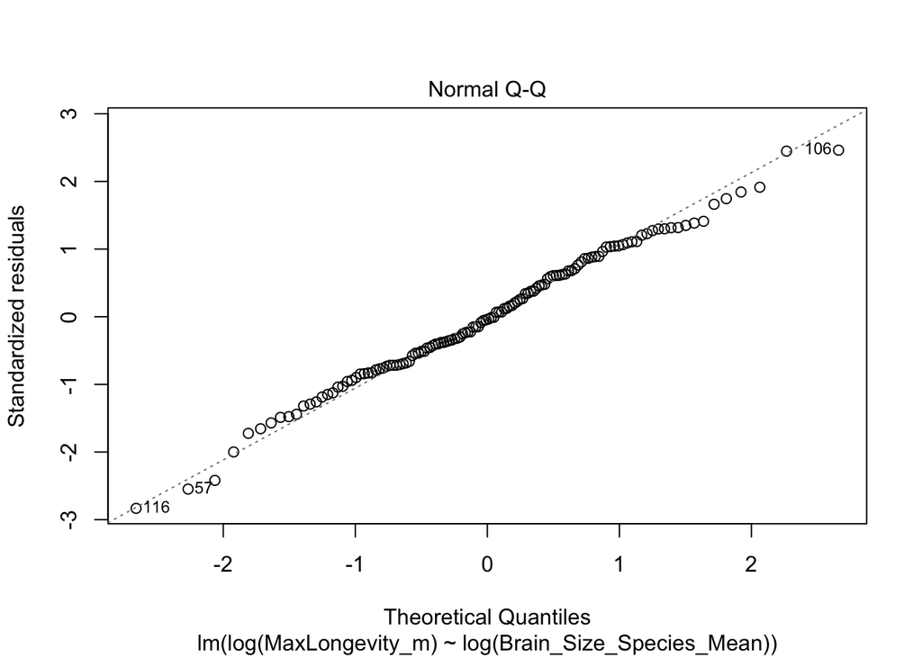

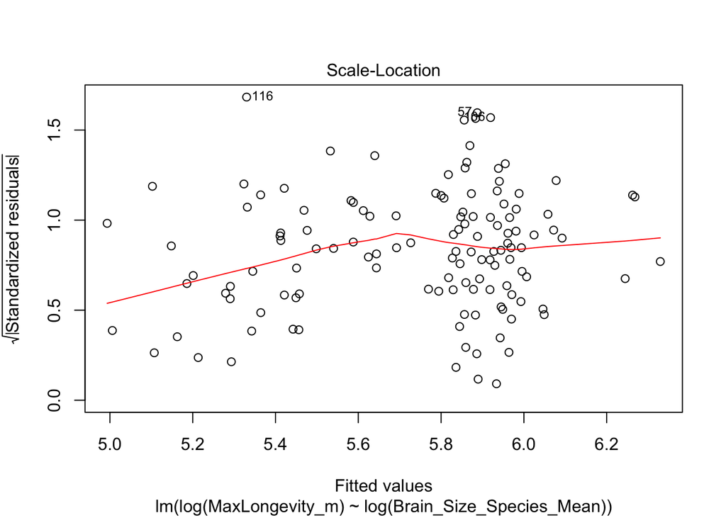

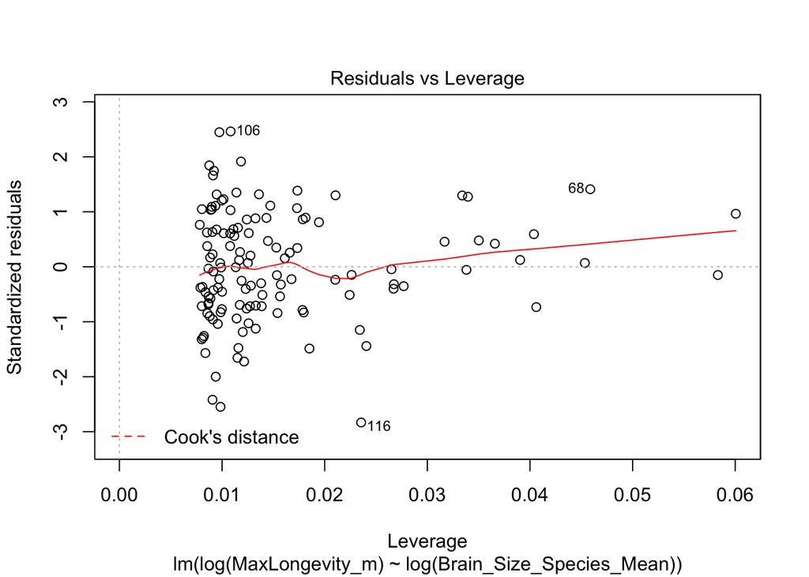

```r
plot(m)
```

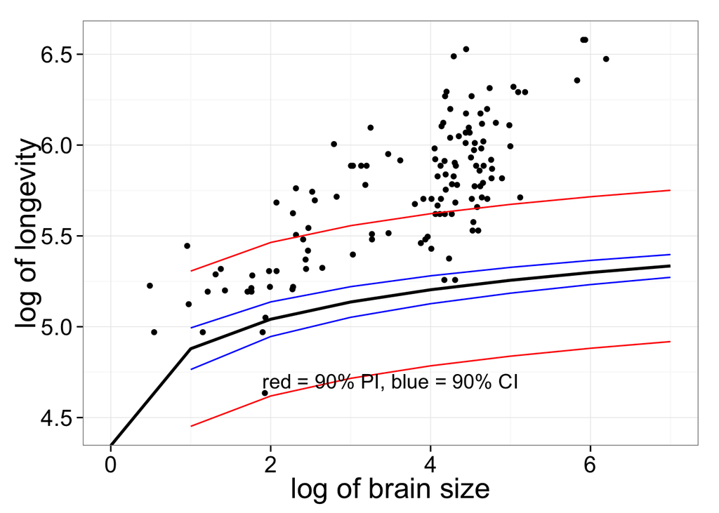

```r
ggplot(data = d, aes(x = log(Brain_Size_Species_Mean), y = log(MaxLongevity_m))) +
  geom_point()+
  geom_line(data = df, aes(x = v, y = CIfit), colour = "black", lwd = 1)+
  geom_line(data = df, aes(x = v, y = CIlwr), colour = "blue")+
  geom_line(data = df, aes(x = v, y = CIupr), colour = "blue")+
  geom_line(data = df, aes(x = v, y = PIlwr), colour = "red")+
  geom_line(data = df, aes(x = v, y = PIupr), colour = "red")+
  annotate("text", x = 3.5, y = 4.7, label = "red = 90% PI, blue = 90% CI")+
  ylab("log of longevity")+
  theme_bw(20) +
  xlab("log of brain size")
```

Do you trust the model to predict observations accurately for this value of the explanatory variable? Why or why not? Looking at your two models, which do you think is better? Why?

NOTE: my log model seems flawed - and the 0 point yields an error and the predicted and CI fits don’t seem very accurate. This certainly is a factor to consider when deciding which model is the more accurate..

Also when we ran our shapiro tests, the log model was non-significantly non-normal (i.e. normally distributed), because the P-value was 0.7404. But the non-log model was significantly non-normal (P=0.0001729).